# Predicting Daily Ticket Sales for Swimming Pools in Albuquerque

Istvan Janco #2003877

2/12/2021

## Outline

#### 1. Business Problem

#### 2. Data

#### 3. Analysis

#### 4. Modeling

#### 5. Conclusion

#### GitHub: https://github.com/steveJ34/DA3_assignment3

## 1. Business Problem

This study is examining ticket sales for outdoor swimming pools based on data from Albuquerque, US. The specific objective is to predict the volume of ticket sales for 12 month into the future for each day.

## 3. Analysis

The beol graphs present the trends and seasonality within the data. Figure 1 shows the trend of ticket sales for 2015.

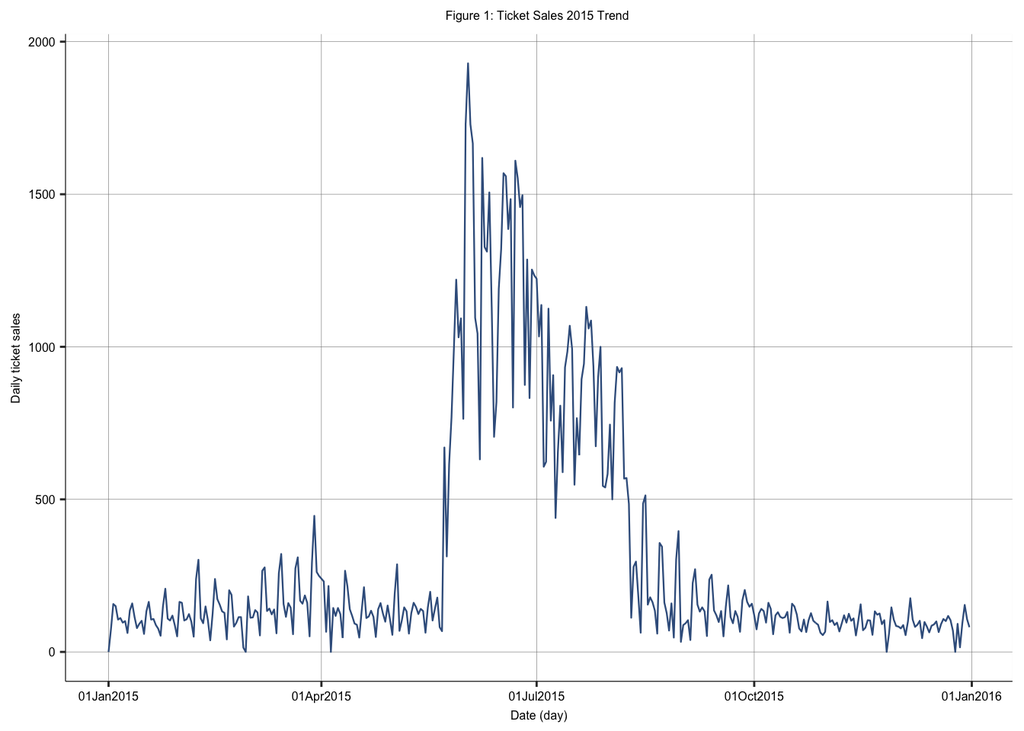

It is looks like the ticket sales are below 500 pieces per day at the beginning of the year, however as we move closer to spring and then summer, it starts increasing, and almost reached 2000 per day, but once the warm season is over, the sales revert back to the original quantities. This clearly indicates a associaion between season of the year and weather conditions. In order to further examone the dependencies, let’s zoom out and take a look at sales starting from 2010.

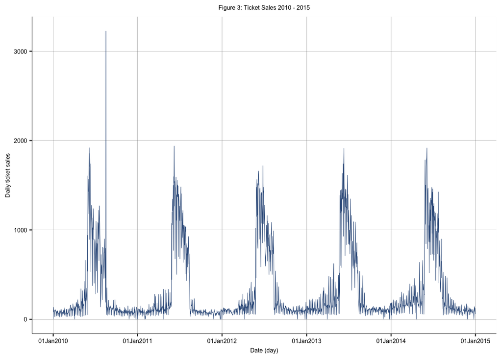

It seems that the aforementioned variatatio repeats itself every year since 2010, we can assume that there is seasonality in the sales of volume of ticket sales.

In order to capture the magnitude of variation, let’s consider the below box plot.

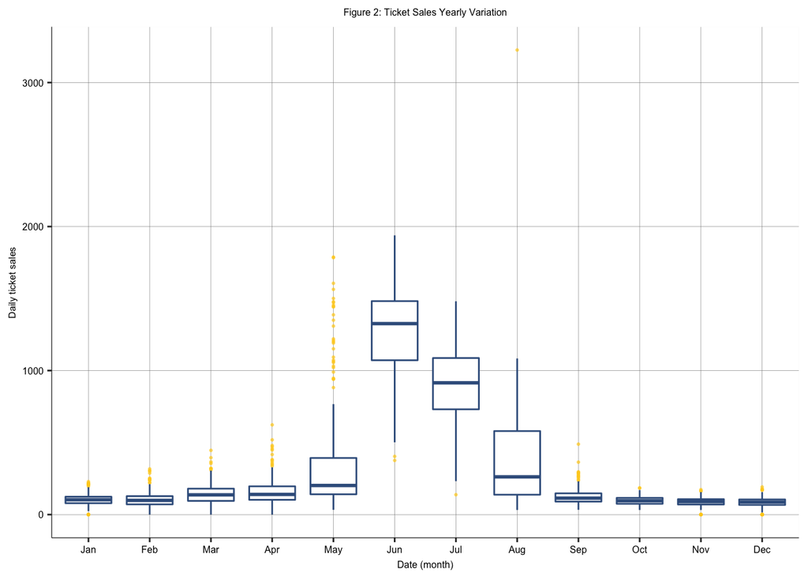

The figure clearly indicates that the number of visitors drastically increases in the summer, with June in July being the busiest.

The weekly box plot (Figure 4), suggests that Saturday and Sunday being the most popular days, and suprisingly Friday is indicated as the least popular visiting day.

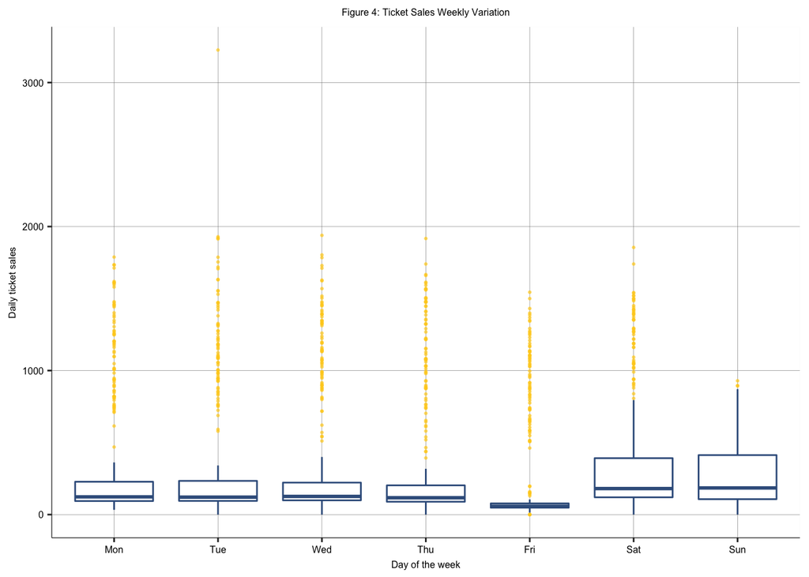

The above charts suggest significant variation in both monthly and weekly ticket sale, thus we should investigate if the there is relation between the variations on these levels. The below heatmap suggests that there indeed there is a correlation. The vertical axis shows the month of the year, while the horizontal outlines the days of the week.

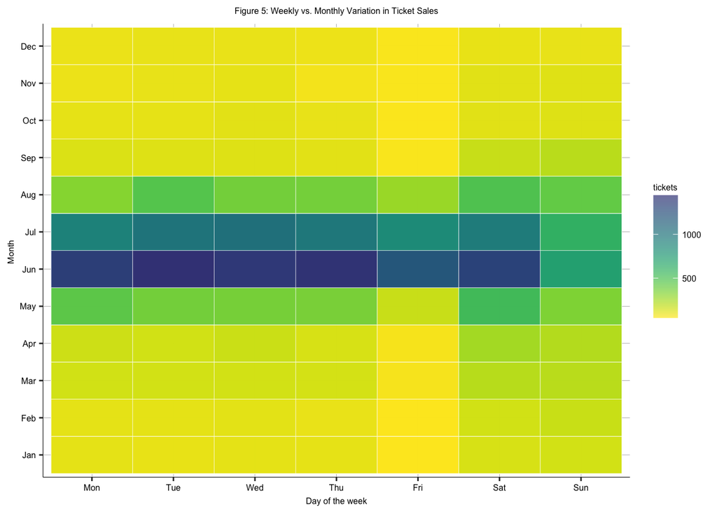

The rectangles indicate the average number of visitors for every given day for a certain month (e.g. average number of visitors for every Monday in July). It is evident that the average number of visitors is higher in June and July, for every day of the week.

## 4. Modeling

The below table outlines the models that were used for prediction.

Table 1: Logit Variables

| X1 | X2 | X3 | X4 | X5 | X6..Log. |
| --- | --- | --- | --- | --- | --- |
| linear trend | linear trend | linear trend | linear trend | linear trend | linear trend |
| monthly seasonality | monthly seasonality | monthly seasonality | monthly seasonality | monthly seasonality | monthly seasonality |
|  | days of week seasonality | days of week seasonality | days of week seasonality | days of week seasonality | days of week seasonality |
|  |  | holidays | School off * dow | School off * dow | School off * dow |
|  |  |  |  | Days*Months |  |

The models are built with progressing complexity. The simplest model includes the seasonality and dummy for the for month. The second model also includes binary variable for day of week. Holidays are built in to the third model. Model 4 adds the interaction of days of week with school holidays. In order to capture the interaction between weekends and month (to capture the interaction suggested by the heatmap). Model 6 is similar to Model 4 in terms of predictors, however the outcome variable is log-transformed.

Table 2: Model Performance

|  | x |
| --- | --- |
| reg1 | 203.3908 |
| reg2 | 199.4154 |
| reg3 | 199.0835 |
| reg4 | 181.1933 |
| reg5 | 178.2359 |
| reg6 | 230.1635 |

The above summary (Table 2), suggests the that the best performing model is five. The results are based on a 6 fold cross validation, using the yearly data as separate folds, in order to maintain the serial correlation.

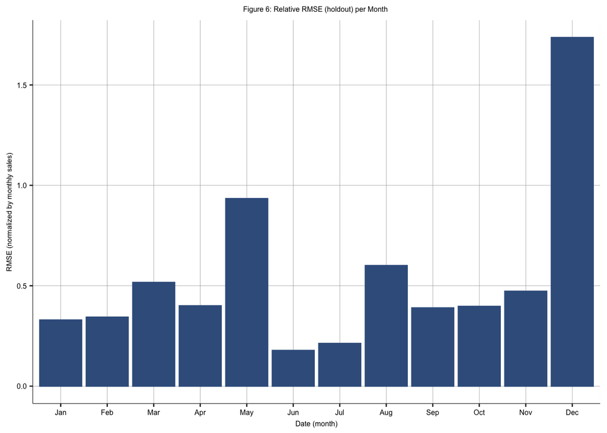

Let’s take a look at how the chosen model actually performs on the holdout data and compare the value predicted by model 5 to the actual values. The graph suggests that the model is able to capture the seasonal variation in the data, thus we can conclude that that the patterns in the data are stable.

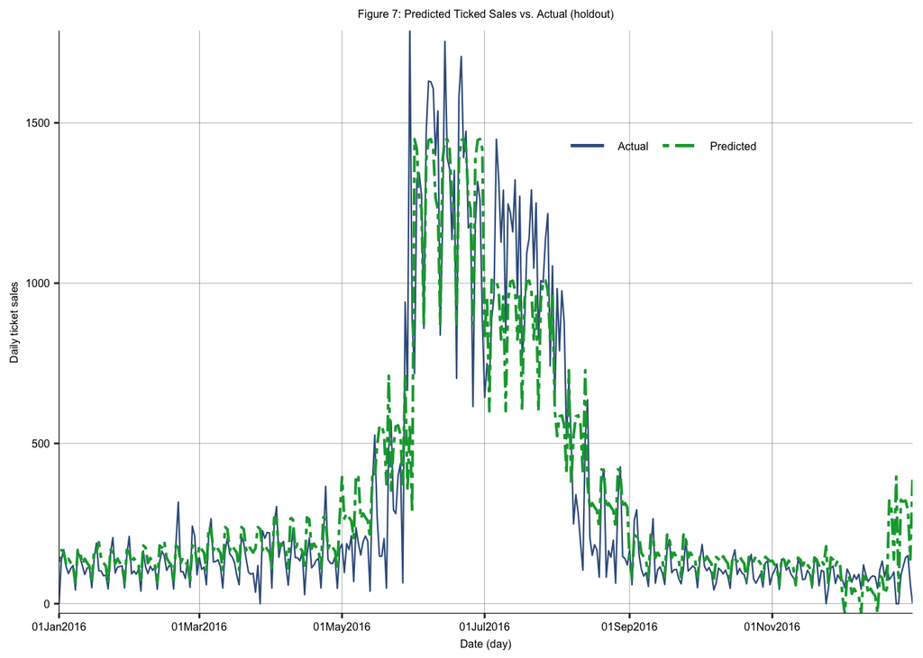

## 5. Conclusion

The case study was aimed to predict the volume of ticket sales for open air pools in Albuquerque. The used data included transaction level data. The chosen model (based on CV RMSE) included variables like linear trend and different dummies, indicating seasonality. It was able to capture the seasonal variation in the holdout and training set, however, the model tends to make errors in months where there are longer holidays, such as December. In order to improve the model performance, it would be beneficial to new variables, like the weather conditions or dummy variable to indicate if it was cold on a given day. In addition, using a different prediction algorithm such as Prophet would have the potentila to improve prediction, however due to technical reasons the package could not be used for the current case study.